# R Scripting and Markdown

Christopher Bennett

# R Script:

#### An R script is simply a text file containing the same commands that you would enter on the command line

## Advantages of Scripting:

1. Make reproducible analyses
2. Easy to make changes to analyses
3. Scripts can be shared with collaborators, reviewers, and colleagues
4. Hands off and simple to run

## Elements of R Scripts:

1. **Settings**:
   - Libraries
   - Input and Output directory
2. **Input**:
   - Load data to be processes
   - Arguments
3. **Processes**:
   - Cleaning
   - Statistical Analyses
   - Plots
4. **Output**:
   - Figures
   - Tables
   - Data
   - Results

## Download and set R packages

### By Menu in R Studio

- Menu > Tools > Install Packages > Type name in Packages field
- Packages Window > Check packages

### By Command

```r
install.packages("ggplot2")
```

```r
library(ggplot2)
?require()
```

```
## starting httpd help server ... done
```

## Set Working Directory

### Selecting a Working Directory by menu in R Studio

- Menu > Session > Set Working Directory
- Environment window > Files > More > Set As Working Directory / Go To Working Directory

### Selecting a Working Directory by command

```r
getwd()
```

```
## [1] "C:/Users/Christopher/Documents/Teaching_materials/Nanocourse_R_II_Jan2019"
```

```r
setwd("rscripting_workshop/")
list.files()
```

```
## [1] "example_script.R"       "exp_plot.R"             "mtcars.csv"
## [4] "multi_plots.R"          "rscripting.html"        "rscripting.Rmd"
## [7] "RScripting_Slides.R"    "rscriptingAnswers.html" "rscriptingAnswers.Rmd"
```

## Data Input: reading data from a file

```r
?read.table
```

```r
setwd("rscripting_workshop/")
tbl <- read.table(file="mtcars.csv", sep=',', header=TRUE)
head(tbl)
```

|  | model | mpg | cyl | disp | hp | drat | wt | qsec | vs | am | gear | carb |
| --- | --- | --- | --- | --- | --- | --- | --- | --- | --- | --- | --- | --- |
| 1 | Mazda RX4 | 21.0 | 6 | 160 | 110 | 3.90 | 2.620 | 16.46 | 0 | 1 | 4 | 4 |
| 2 | Mazda RX4 Wag | 21.0 | 6 | 160 | 110 | 3.90 | 2.875 | 17.02 | 0 | 1 | 4 | 4 |
| 3 | Datsun 710 | 22.8 | 4 | 108 | 93 | 3.85 | 2.320 | 18.61 | 1 | 1 | 4 | 1 |
| 4 | Hornet 4 Drive | 21.4 | 6 | 258 | 110 | 3.08 | 3.215 | 19.44 | 1 | 0 | 3 | 1 |
| 5 | Hornet Sportabout | 18.7 | 8 | 360 | 175 | 3.15 | 3.440 | 17.02 | 0 | 0 | 3 | 2 |
| 6 | Valiant | 18.1 | 6 | 225 | 105 | 2.76 | 3.460 | 20.22 | 1 | 0 | 3 | 1 |

### Row and column names

```r
setwd("rscripting_workshop/")
tbl <- read.table(file="mtcars.csv", sep=',', header=TRUE, row.names=1)
row.names(tbl)
```

```
##  [1] "Mazda RX4"           "Mazda RX4 Wag"       "Datsun 710"
##  [4] "Hornet 4 Drive"      "Hornet Sportabout"   "Valiant"
##  [7] "Duster 360"          "Merc 240D"           "Merc 230"
## [10] "Merc 280"            "Merc 280C"           "Merc 450SE"
## [13] "Merc 450SL"          "Merc 450SLC"         "Cadillac Fleetwood"
## [16] "Lincoln Continental" "Chrysler Imperial"   "Fiat 128"
## [19] "Honda Civic"         "Toyota Corolla"      "Toyota Corona"
## [22] "Dodge Challenger"    "AMC Javelin"         "Camaro Z28"
## [25] "Pontiac Firebird"    "Fiat X1-9"           "Porsche 914-2"
## [28] "Lotus Europa"        "Ford Pantera L"      "Ferrari Dino"
## [31] "Maserati Bora"       "Volvo 142E"
```

```r
rownames(tbl)
```

```
##  [1] "Mazda RX4"           "Mazda RX4 Wag"       "Datsun 710"
##  [4] "Hornet 4 Drive"      "Hornet Sportabout"   "Valiant"
##  [7] "Duster 360"          "Merc 240D"           "Merc 230"
## [10] "Merc 280"            "Merc 280C"           "Merc 450SE"
## [13] "Merc 450SL"          "Merc 450SLC"         "Cadillac Fleetwood"
## [16] "Lincoln Continental" "Chrysler Imperial"   "Fiat 128"
## [19] "Honda Civic"         "Toyota Corolla"      "Toyota Corona"
## [22] "Dodge Challenger"    "AMC Javelin"         "Camaro Z28"
## [25] "Pontiac Firebird"    "Fiat X1-9"           "Porsche 914-2"
## [28] "Lotus Europa"        "Ford Pantera L"      "Ferrari Dino"
## [31] "Maserati Bora"       "Volvo 142E"
```

```r
colnames(tbl)
```

```
##  [1] "mpg"  "cyl"  "disp" "hp"   "drat" "wt"   "qsec" "vs"   "am"   "gear"
## [11] "carb"
```

```r
names(tbl)
```

```
##  [1] "mpg"  "cyl"  "disp" "hp"   "drat" "wt"   "qsec" "vs"   "am"   "gear"
## [11] "carb"
```

### Slicing Dataframes

```r
head(tbl)
```

|  | mpg | cyl | disp | hp | drat | wt | qsec | vs | am | gear | carb |
| --- | --- | --- | --- | --- | --- | --- | --- | --- | --- | --- | --- |
| Mazda RX4 | 21.0 | 6 | 160 | 110 | 3.90 | 2.620 | 16.46 | 0 | 1 | 4 | 4 |
| Mazda RX4 Wag | 21.0 | 6 | 160 | 110 | 3.90 | 2.875 | 17.02 | 0 | 1 | 4 | 4 |
| Datsun 710 | 22.8 | 4 | 108 | 93 | 3.85 | 2.320 | 18.61 | 1 | 1 | 4 | 1 |
| Hornet 4 Drive | 21.4 | 6 | 258 | 110 | 3.08 | 3.215 | 19.44 | 1 | 0 | 3 | 1 |
| Hornet Sportabout | 18.7 | 8 | 360 | 175 | 3.15 | 3.440 | 17.02 | 0 | 0 | 3 | 2 |
| Valiant | 18.1 | 6 | 225 | 105 | 2.76 | 3.460 | 20.22 | 1 | 0 | 3 | 1 |

```r
tbl2 <- tbl[1:5,1:5]
head(tbl2)
```

|  | mpg | cyl | disp | hp | drat |
| --- | --- | --- | --- | --- | --- |
| Mazda RX4 | 21.0 | 6 | 160 | 110 | 3.90 |
| Mazda RX4 Wag | 21.0 | 6 | 160 | 110 | 3.90 |
| Datsun 710 | 22.8 | 4 | 108 | 93 | 3.85 |
| Hornet 4 Drive | 21.4 | 6 | 258 | 110 | 3.08 |
| Hornet Sportabout | 18.7 | 8 | 360 | 175 | 3.15 |

```r
tbl3 <- tbl[1:10,]
head(tbl3)
```

|  | mpg | cyl | disp | hp | drat | wt | qsec | vs | am | gear | carb |
| --- | --- | --- | --- | --- | --- | --- | --- | --- | --- | --- | --- |
| Mazda RX4 | 21.0 | 6 | 160 | 110 | 3.90 | 2.620 | 16.46 | 0 | 1 | 4 | 4 |
| Mazda RX4 Wag | 21.0 | 6 | 160 | 110 | 3.90 | 2.875 | 17.02 | 0 | 1 | 4 | 4 |
| Datsun 710 | 22.8 | 4 | 108 | 93 | 3.85 | 2.320 | 18.61 | 1 | 1 | 4 | 1 |
| Hornet 4 Drive | 21.4 | 6 | 258 | 110 | 3.08 | 3.215 | 19.44 | 1 | 0 | 3 | 1 |
| Hornet Sportabout | 18.7 | 8 | 360 | 175 | 3.15 | 3.440 | 17.02 | 0 | 0 | 3 | 2 |
| Valiant | 18.1 | 6 | 225 | 105 | 2.76 | 3.460 | 20.22 | 1 | 0 | 3 | 1 |

```r
tbl4 <- tbl[,4:8]
head(tbl4)
```

|  | hp | drat | wt | qsec | vs |
| --- | --- | --- | --- | --- | --- |
| Mazda RX4 | 110 | 3.90 | 2.620 | 16.46 | 0 |
| Mazda RX4 Wag | 110 | 3.90 | 2.875 | 17.02 | 0 |
| Datsun 710 | 93 | 3.85 | 2.320 | 18.61 | 1 |
| Hornet 4 Drive | 110 | 3.08 | 3.215 | 19.44 | 1 |
| Hornet Sportabout | 175 | 3.15 | 3.440 | 17.02 | 0 |
| Valiant | 105 | 2.76 | 3.460 | 20.22 | 1 |

## Processes

### Programming Functions

- Loops
  - *for* and *while*
- Conditional statements
  - *if* and *else*
- Functions
  - user-defined calculations
  - calling on 3rd party or built-in functions

#### FOR loops

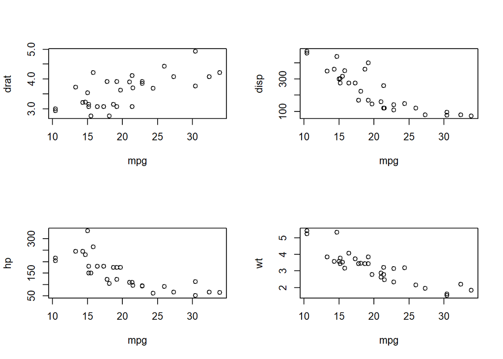

```r
Ys <- c("drat", "disp", "hp","wt")
x <- tbl$mpg
par(mfrow=c(2,2))
for (i in 1:4) {
  y <- tbl[, Ys[i]]
  plot(x,y,xlab="mpg",ylab=Ys[i])
}
```

```r
tbl$mpgpwt <- 0
rows <- nrow(tbl)
for(i in 1:rows){
  mpg <- tbl$mpg[i]
  wt <- tbl$wt[i]
  tbl$mpgpwt[i] <- mpg/wt
}
head(tbl)
```

|  | mpg | cyl | disp | hp | drat | wt | qsec | vs | am | gear | carb | mpgpwt |
| --- | --- | --- | --- | --- | --- | --- | --- | --- | --- | --- | --- | --- |
| Mazda RX4 | 21.0 | 6 | 160 | 110 | 3.90 | 2.620 | 16.46 | 0 | 1 | 4 | 4 | 8.015267 |
| Mazda RX4 Wag | 21.0 | 6 | 160 | 110 | 3.90 | 2.875 | 17.02 | 0 | 1 | 4 | 4 | 7.304348 |
| Datsun 710 | 22.8 | 4 | 108 | 93 | 3.85 | 2.320 | 18.61 | 1 | 1 | 4 | 1 | 9.827586 |
| Hornet 4 Drive | 21.4 | 6 | 258 | 110 | 3.08 | 3.215 | 19.44 | 1 | 0 | 3 | 1 | 6.656299 |
| Hornet Sportabout | 18.7 | 8 | 360 | 175 | 3.15 | 3.440 | 17.02 | 0 | 0 | 3 | 2 | 5.436047 |
| Valiant | 18.1 | 6 | 225 | 105 | 2.76 | 3.460 | 20.22 | 1 | 0 | 3 | 1 | 5.231214 |

#### Nested FOR loops

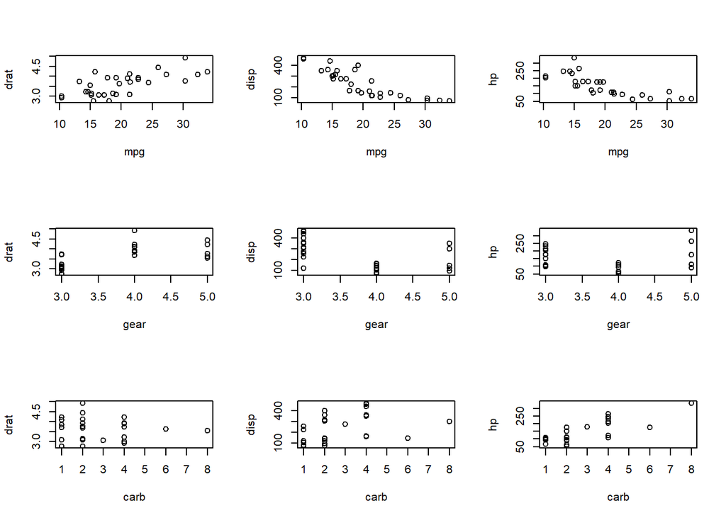

```r
Ys <- c("drat", "disp", "hp")
Xs <- c("mpg", "gear", "carb")
par(mfrow=c(3,3))
for (i in 1:3) {
  x <- tbl[, Xs[i]]
  for (j in 1:3) {
    y <- tbl[,Ys[j]]
    plot(x,y,xlab=Xs[i], ylab=Ys[j])
  }
}
```

#### WHILE loops

```r
i <- 0
square <- 0
while (square <88) {
  i <- i+1
  square <- i*i
}
i-1
```

```
## [1] 9
```

#### IF statements

```r
x<-2
if (x>0) {
  log.x <- log2(x)
}
log.x
```

```
## [1] 1
```

#### IF-ELSE statements

```r
x <- 0.1
if (x>1) {
  log.x <- log2(x)
} else {
  log.x <- 0
}
log.x
```

```
## [1] 0
```

```r
tbl$goodmile <- NA
rows <- nrow(tbl)
for(i in 1:rows){
  mpg <- tbl$mpg[i]
  if(mpg > 24){
    tbl$goodmile[i] <- 'Yes'
  } else {
    tbl$goodmile[i] <- 'No'
  }

}
head(tbl)
```

|  | mpg | cyl | disp | hp | drat | wt | qsec | vs | am | gear | carb | mpgpwt | goodmile |
| --- | --- | --- | --- | --- | --- | --- | --- | --- | --- | --- | --- | --- | --- |
| Mazda RX4 | 21.0 | 6 | 160 | 110 | 3.90 | 2.620 | 16.46 | 0 | 1 | 4 | 4 | 8.015267 | No |
| Mazda RX4 Wag | 21.0 | 6 | 160 | 110 | 3.90 | 2.875 | 17.02 | 0 | 1 | 4 | 4 | 7.304348 | No |
| Datsun 710 | 22.8 | 4 | 108 | 93 | 3.85 | 2.320 | 18.61 | 1 | 1 | 4 | 1 | 9.827586 | No |
| Hornet 4 Drive | 21.4 | 6 | 258 | 110 | 3.08 | 3.215 | 19.44 | 1 | 0 | 3 | 1 | 6.656299 | No |
| Hornet Sportabout | 18.7 | 8 | 360 | 175 | 3.15 | 3.440 | 17.02 | 0 | 0 | 3 | 2 | 5.436047 | No |
| Valiant | 18.1 | 6 | 225 | 105 | 2.76 | 3.460 | 20.22 | 1 | 0 | 3 | 1 | 5.231214 | No |

### Controlling loops

- BREAK
  - In a conditional statement to stop the loop
- NEXT
  - In a conditional statement to skip the analysis for certain rounds of the loop

#### REPEAT and BREAK

Without a “break” conditional repeats are infinite loops!

```r
i <- 0
square <- 0
repeat {
  i <- i+1
  square <- i^2
  if (square > 88) {
    break
  }
}
i-1
```

```
## [1] 9
```

#### NEXT in a FOR loop

```r
sum <- 0
num.cars <- 0
for (i in 1:length(tbl$mpg)) {
  if (tbl$cyl[i] > 6) {
    next
  } else {
    sum <- sum + tbl$mpg[i]
    num.cars <- num.cars+1
  }
}
avg.mpg <- sum/num.cars
sum
```

```
## [1] 431.5
```

```r
num.cars
```

```
## [1] 18
```

```r
avg.mpg
```

```
## [1] 23.97222
```

### Useful function: AGGREGATE

```r
?aggregate
aggregate(mpg ~ cyl, tbl, mean)
```

| cyl | mpg |
| --- | --- |
| 4 | 26.66364 |
| 6 | 19.74286 |
| 8 | 15.10000 |

```r
aggregate(. ~ cyl, tbl[,-13], median)
```

[output not shown]

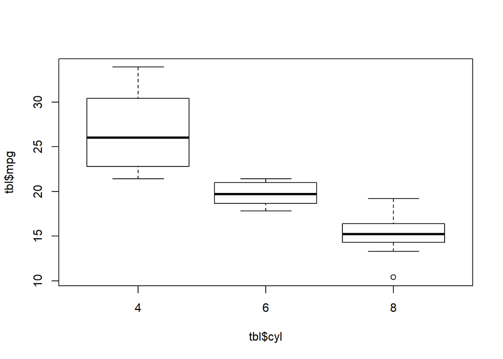

```r
boxplot(tbl$mpg ~ tbl$cyl)
```

### Useful function: SUMMARY

```r
?summary
summary(tbl)
```

```
##       mpg             cyl             disp             hp
##  Min.   :10.40   Min.   :4.000   Min.   : 71.1   Min.   : 52.0
##  1st Qu.:15.43   1st Qu.:4.000   1st Qu.:120.8   1st Qu.: 96.5
##  Median :19.20   Median :6.000   Median :196.3   Median :123.0
##  Mean   :20.09   Mean   :6.188   Mean   :230.7   Mean   :146.7
##  3rd Qu.:22.80   3rd Qu.:8.000   3rd Qu.:326.0   3rd Qu.:180.0
##  Max.   :33.90   Max.   :8.000   Max.   :472.0   Max.   :335.0
##       drat             wt             qsec             vs
##  Min.   :2.760   Min.   :1.513   Min.   :14.50   Min.   :0.0000
##  1st Qu.:3.080   1st Qu.:2.581   1st Qu.:16.89   1st Qu.:0.0000
##  Median :3.695   Median :3.325   Median :17.71   Median :0.0000
##  Mean   :3.597   Mean   :3.217   Mean   :17.85   Mean   :0.4375
##  3rd Qu.:3.920   3rd Qu.:3.610   3rd Qu.:18.90   3rd Qu.:1.0000
##  Max.   :4.930   Max.   :5.424   Max.   :22.90   Max.   :1.0000
##        am              gear            carb           mpgpwt
##  Min.   :0.0000   Min.   :3.000   Min.   :1.000   Min.   : 1.917
##  1st Qu.:0.0000   1st Qu.:3.000   1st Qu.:2.000   1st Qu.: 4.353
##  Median :0.0000   Median :4.000   Median :2.000   Median : 5.509
##  Mean   :0.4062   Mean   :3.688   Mean   :2.812   Mean   : 7.495
##  3rd Qu.:1.0000   3rd Qu.:4.000   3rd Qu.:4.000   3rd Qu.: 8.192
##  Max.   :1.0000   Max.   :5.000   Max.   :8.000   Max.   :20.093
##    goodmile
##  Length:32
##  Class :character
##  Mode  :character
##
##
##
```

### Useful function: REPLICATE

```r
replicate(5, seq(1:5))
```

```
##      [,1] [,2] [,3] [,4] [,5]
## [1,]    1    1    1    1    1
## [2,]    2    2    2    2    2
## [3,]    3    3    3    3    3
## [4,]    4    4    4    4    4
## [5,]    5    5    5    5    5
```

```r
replicate(12, rnorm(10))
```

```
##              [,1]        [,2]       [,3]       [,4]        [,5]        [,6]
##  [1,] -1.55026736 -2.19512950 -0.1570708 -0.6787019 -0.25450380 -0.18742807
##  [2,]  0.08295180 -0.38851006  1.7187128 -1.3113888 -1.21550608  0.09164374
##  [3,]  0.15290182  0.48080820  1.2579397 -0.8766610  0.71769454  0.85221214
##  [4,] -0.43121749  0.97594936 -0.6696199  0.8543686  0.08985533 -1.33665173
##  [5,] -0.46428652 -0.66470795 -0.1951887 -1.1901579  0.30405496 -0.93455528
##  [6,] -0.13157876  0.59826122 -0.9045491 -1.0983529 -2.18780414 -0.22859671
##  [7,]  0.05857045  0.03113747  1.0993092 -0.6224776 -0.19186612  0.82823251
##  [8,] -0.26740596  0.23295991  2.2867963  0.3056667 -0.76883342  0.14742927
##  [9,]  0.80971304  0.47406374 -1.1092866 -0.7793306  0.27086555 -0.09328440
## [10,]  0.88117487 -0.08126959  0.5192092 -0.4689713 -1.29832158  1.29208730
##             [,7]       [,8]       [,9]      [,10]      [,11]       [,12]
##  [1,]  0.4274198  0.9629745 -0.3689540  0.9425910 -0.9471809  0.93528241
##  [2,] -0.3253880 -0.1547081  0.4504618 -0.9036139 -0.3680969 -1.00241918
##  [3,] -1.8512466 -0.6188728 -1.5875876 -1.6221394 -0.7656621  1.10732101
##  [4,]  0.3324729  0.2559932  0.3972468 -0.2281412 -0.8445924  1.39383595
##  [5,] -0.1540986 -2.3151297  1.6884054 -0.1987367  0.9654218  0.38443839
##  [6,] -0.5744457 -0.1797082 -0.7754248 -0.5602243 -0.1429621  0.28534873
##  [7,]  0.6054755 -1.1874158 -0.2974875  0.8623126 -1.9018088  0.12072938
##  [8,]  0.9500299  0.3853426  0.2787959  0.5107394  0.2542846 -0.71535108
##  [9,] -0.2433233 -0.5286362  0.4333479 -0.9038539  2.2221066 -2.50027325
## [10,]  1.3619103  1.0385253 -0.8268420  0.7035540 -2.2746536  0.07919809
```

### User defined functions

There are lots of built-in functions in R. But, sometimes, you need to make custom code for a process.

Functions are just a set of instructions(calculations) that we want to use repeatedly or that, because of their complexity, are better self-contained in a sub-program and called when needed.

#### Basic FUNCTION elements

```r
function.name <- function(arguments)
{
  #computations on the arguments
  #and some other code
}
```

```r
square <- function(x)
{
  x^2
}

square(40)
```

```
## [1] 1600
```

```r
k <- 10
square(k)
```

```
## [1] 100
```

#### Setting a default value or range

```r
square <- function(x=10, n=seq(0.05, 1, by=0.01))
{
  x^n
}
square(2,5)
```

```
## [1] 32
```

```r
square(,2)
```

```
## [1] 100
```

```r
square(2,)
```

```
##  [1] 1.035265 1.042466 1.049717 1.057018 1.064370 1.071773 1.079228 1.086735
##  [9] 1.094294 1.101905 1.109569 1.117287 1.125058 1.132884 1.140764 1.148698
## [17] 1.156688 1.164734 1.172835 1.180993 1.189207 1.197479 1.205808 1.214195
## [25] 1.222640 1.231144 1.239708 1.248331 1.257013 1.265757 1.274561 1.283426
## [33] 1.292353 1.301342 1.310393 1.319508 1.328686 1.337928 1.347234 1.356604
## [41] 1.366040 1.375542 1.385109 1.394744 1.404445 1.414214 1.424050 1.433955
## [49] 1.443929 1.453973 1.464086 1.474269 1.484524 1.494849 1.505247 1.515717
## [57] 1.526259 1.536875 1.547565 1.558329 1.569168 1.580083 1.591073 1.602140
## [65] 1.613284 1.624505 1.635804 1.647182 1.658639 1.670176 1.681793 1.693491
## [73] 1.705270 1.717131 1.729074 1.741101 1.753211 1.765406 1.777685 1.790050
## [81] 1.802501 1.815038 1.827663 1.840375 1.853176 1.866066 1.879045 1.892115
## [89] 1.905276 1.918528 1.931873 1.945310 1.958841 1.972465 1.986185 2.000000
```

### Calling functions in a function

```r
my.fun <- function(X.matrix, y.vec, z.scalar)
{
  sq.scalar <- square(z.scalar,2)
  mult <- X.matrix %*% y.vec
  final <- mult * sq.scalar
  return(final)
}

my.mat <- matrix(c(1:6),3,2)
my.vec <- c(3:4)

my.fun(my.mat, my.vec, 5)
```

```
##      [,1]
## [1,]  475
## [2,]  650
## [3,]  825
```

### Function returning a List

```r
my.fun <- function(X.matrix, y.vec, z.scalar)
{
  sq.scalar <- square(z.scalar,2)
  mult <- X.matrix %*% y.vec
  final <- mult * sq.scalar
  return(list(sq.num=sq.scalar, matmult=final))
}

my.fun(my.mat, my.vec, 5)
```

```
## $sq.num
## [1] 25
##
## $matmult
##      [,1]
## [1,]  475
## [2,]  650
## [3,]  825
```

### Function Best Practices

- keep your functions short.
- If things start to get very long, you can probably split up your function into more manageable chunks that call other functions. This makes your code cleaner and easily testable.
- Functions make your code easy to update. You only have to change one function and every other function that uses that function will also be automatically updated.
- Put in comments on what are the inputs to the function, what the function does, and what is the output.
- Check for errors along the way.
- Try out your function with simple examples to make sure it’s working properly.

### APPLY functions

- The APPLY family can be used to perform functions to manipulate slices of data from matrices, arrays, lists and data frames in a repetitive way.
- ‘apply’ - operates on array or matrix
- ‘lapply’ and ‘sapply’ - traversing over a set of data like a list or vector, and calling the specified function for each item. sapply return a vector and lapply returns a list
- ‘mapply’ - multivariate apply.
- ‘tapply’ - applies a function to each cell of an array

```r
# (N)apply(X, MARGIN, FUN, ...)
```

- apply

```r
apply(tbl[-13], 2, sum) #sum of each column in tbl
```

```
##       mpg       cyl      disp        hp      drat        wt      qsec        vs
##  642.9000  198.0000 7383.1000 4694.0000  115.0900  102.9520  571.1600   14.0000
##        am      gear      carb    mpgpwt
##   13.0000  118.0000   90.0000  239.8352
```

```r
ColMax <- function(x) apply(x,2,max)
ColMax(tbl[-13])
```

```
##       mpg       cyl      disp        hp      drat        wt      qsec        vs
##  33.90000   8.00000 472.00000 335.00000   4.93000   5.42400  22.90000   1.00000
##        am      gear      carb    mpgpwt
##   1.00000   5.00000   8.00000  20.09253
```

- sapply/lapply

```r
sapply(1:3, function(x) x^2)
```

```
## [1] 1 4 9
```

```r
lapply(1:3, function(x) x^2)
```

```
## [[1]]
## [1] 1
##
## [[2]]
## [1] 4
##
## [[3]]
## [1] 9
```

- mapply

```r
mapply(rep, 1:4, 4:1)
```

```
## [[1]]
## [1] 1 1 1 1
##
## [[2]]
## [1] 2 2 2
##
## [[3]]
## [1] 3 3
##
## [[4]]
## [1] 4
```

- tapply

```r
tapply(tbl$mpg, tbl$cyl, mean)
```

```
##        4        6        8
## 26.66364 19.74286 15.10000
```

#### APPLY for repetitive application

```r
r <- rainbow(3) #rainbow(n): create a vector of n contiguous colors
choose.col <- function(n) {
  if (n>3) {
    col.n <- r[1]
  }
  if (n>5) {
    col.n <- r[2]
  }
  if (n>7) {
    col.n <- r[3]
  }
  col.n
}

col.pch <- sapply(tbl$cyl, choose.col)
cbind(tbl$cyl, col.pch)
```

```
##           col.pch
##  [1,] "6" "#00FF00FF"
##  [2,] "6" "#00FF00FF"
##  [3,] "4" "#FF0000FF"
##  [4,] "6" "#00FF00FF"
##  [5,] "8" "#0000FFFF"
##  [6,] "6" "#00FF00FF"
##  [7,] "8" "#0000FFFF"
##  [8,] "4" "#FF0000FF"
##  [9,] "4" "#FF0000FF"
## [10,] "6" "#00FF00FF"
## [11,] "6" "#00FF00FF"
## [12,] "8" "#0000FFFF"
## [13,] "8" "#0000FFFF"
## [14,] "8" "#0000FFFF"
```

[output cut: 18 more lines]

### Calling functions in Plot

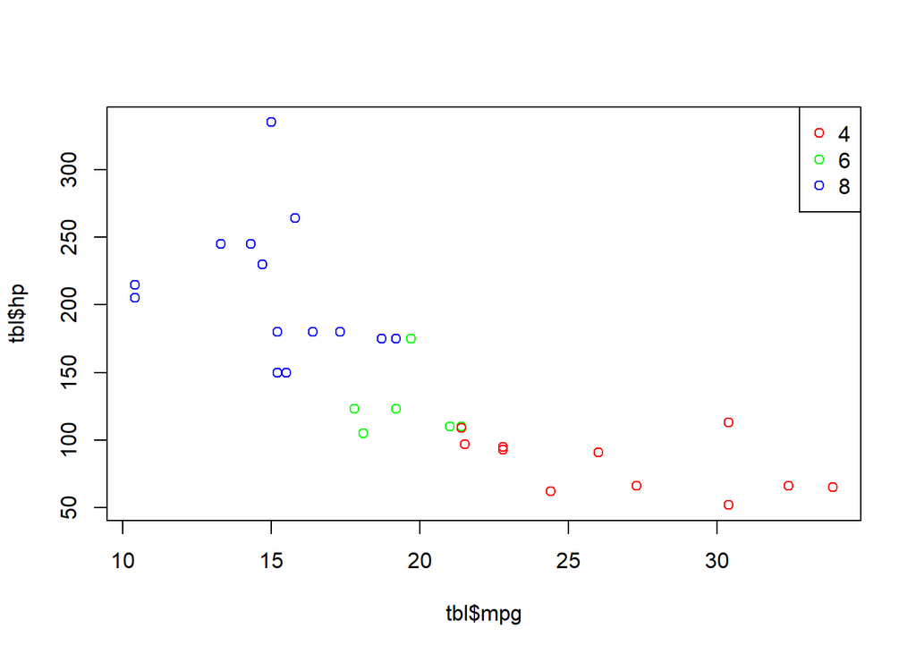

```r
plot(tbl$mpg, tbl$hp, col=sapply(tbl$cyl, choose.col))
legend("topright", legend=c(4,6,8), col=r, pch=1)
```

### Calling functions

- Functions can be stored in the script.
- To use functions in many scripts, they can be saver in their own files or as a function set.
- Use SOURCE to call functions in another file:
  - e.g. source(“square_functions.R”)

## Output:

### Save and Load

- R objects (variables) can be saved into a file:
  - save(mult.list, file=‘mult_list.Rda’)
- Saved objects can be loaded into a new session:
  - load(‘mult_list.Rda’)

### Export a table

- write.csv()
  - write.csv(mydata, "mydata.txt, quote=TRUE, row.names=TRUE)
- write.table()
  - (tab delimited) write.table(mydata, “mydata.txt, sep=”, quote=FALSE, row.names=TRUE)
  - (comma delimited) write.table(mydata, “mydata.txt”, sep=“,”, quote=TRUE, row.names=TRUE)
- write.xlsx()
  - library(xlsx)
  - write.xlsx(mydata, “mydata.xlsx”)

### Graphical outputs

- postscript()
  - postscript(file=“cool_plot.ps”, paper=“letter”, horizontal=TRUE)
- png()
  - pgn(filename=“mpg_by_cyl.png”, width=480, height=480)
- tiff()
  - tiff(filename=“mpg_by_cyl.tiff”, width=480, height=480)

## Putting it all together

```r
r <- rainbow(3) #rainbow(n): create a vector of n contiguous colors
choose.col <- function(n) {
  if (n>3) {
    col.n <- r[1]
  }
  if (n>5) {
    col.n <- r[2]
  }
  if (n>7) {
    col.n <- r[3]
  }
  col.n
}

sep.csv <- c(',') #for tab-delimited# sep.tab <- c('\t')
csv.file <- c("mtcars.csv")
tbl <- read.table(file=csv.file, sep=sep.csv, header=TRUE)

postscript(file="cool_plot.ps", paper="letter", horizontal = TRUE)
plot(tbl$mpg, tbl$hp, col=sapply(tbl$cyl, choose.col))
legend("topright", legend=c(4,6,8), col=r, pch=1)
dev.off()

mpg.cyl <- aggregate(mpg ~ cyl, tbl, mean)
write.table(mpg.cyl, file="mpg_mean_cyl.txt", sep="\t", row.names = FALSE)
png(filename = "mpg_by_cyl.png", width=480, height=480)
boxplot(tbl$mpg ~ tbl$cyl)
dev.off()
```

## Load custom functions as a library

- Allows reuse of custom functions
- Keeps things tidy

```r
source("your_script.R")
```

## Run script

- In Editor, select lines to run and click ‘Run’ icon
- Copy lines to run from Editor and paste them into Consol (+ ENTER)
- On terminal, use ‘Rscript’ command
  - e.g. $ Rscript plot_mpg.R

## Command Line Arguments

- commandArgs
  - accepts values on the command-line and pushes them into an array in the order of the values
- argparse
  - accepts values on the command-line using “command line options”
  - prints out help messages

## commandArgs

- save this block as “exp_plot.R” and remove the #s

```r
args <- commandArgs(TRUE) #get variables from command line
num1 <- as.numeric(args[1])
num2 <- as.numeric(args[2])

square <- function (x,n=seq(1, num2, by=1)) {
  x^n
}

x <- c(1:num2)
y <- square(num1)
png(filename = "exp_plot.png", width = 480, height = 480)
plot(x,y, ylab=paste(num1, "^x", sep=""))
dev.off()
```

- On the command line: $ Rscript exp_plot.R 2 10

## argparse

- save this block as “exp_plot2.R” and remove the #s

```r
library(argparse)
parser <- ArgumentParser()

parser$add_argument("-n", "--number", type="integer", default=2, help="The number that #will be multiplied by itself", metavar="number")

parser$add_argument("-x", "--exponent", type="integer", default=10, help="The number of #the times -n is multiplied itself (exponent)", metavar="number")

args <- parser$parse_args()
num1 <- args$number
num2 <- args$exponent

square <- function (x,n=seq(1, num2, by=1)) {
  x^n
}

x <- c(1:num2)
y <- square(num1)
png(filename = "exp_plot2.png", width = 480, height = 480)
plot(x,y, ylab=paste(num1, "^x", sep=""))
dev.off()
```

# R Markdown

#### An R Markdown is essentially a file combining executable code and plain text with formatting. It’s very useful for exploratory analyses and documenting analysis steps and results.

https://www.rstudio.com/wp-content/uploads/2015/02/rmarkdown-cheatsheet.pdf

# 10-Minute Break before Workshop